# Exploring ncov2019 package

Adela Sobotkova

02-november-2020

# Coronavirus

Coronaviruses (CoV) are a large family of viruses that cause illness ranging from the common cold to more severe diseases such as Middle East Respiratory Syndrome (MERS-CoV) and Severe Acute Respiratory Syndrome (SARS-CoV). A novel coronavirus (nCoV) is a new strain that has not been previously identified in humans. This post is based on a blog post from Guangchuang Yu, a professor of bioinformatics at Southern Medical University, about an R package https://github.com/GuangchuangYu/nCov2019 that contains one of the most up-to-date nCov data in China and all over the world. Patrick Tung has been translating this package from Chinese into English so that it is more accessible to everyone.

https://towardsdatascience.com/an-r-package-to-explore-the-novel-coronavirus-590055738ad6

# Quickstart

To start off, you need to install the `nCov2019` package by running the following command (uncomment/remove the hashtag for the block to run):

```r
#remotes::install_github("GuangchuangYu/nCov2019")
```

Next we attach the library:

```r
library(tidyverse)
library(nCov2019)
```

To get the latest data, you can load it in with `get_nCov2019()`.

```r
x <- get_nCov2019(lang='en')
```

The `x` object you just created is a list. The primary data in it pertains to China, but one of its elements also contains global data.

## Check the data

If you print the data, it will show the total number of confirmed cases in China, as well as the latest updated time:

```r
x
```

```
## China (total confirmed cases): 91966
## last update: 2020-11-02 17:22:22
```

```r
# your dates will differ depending on when you ran it
```

This data is collected from Tencent, at https://news.qq.com/zt2020/page/feiyan.htm, which contains one of the most up-to-date public information of the coronavirus.

## Make a plot of China

If you wanted to visualize the cumulative summary data for China, an example plot could be the following:

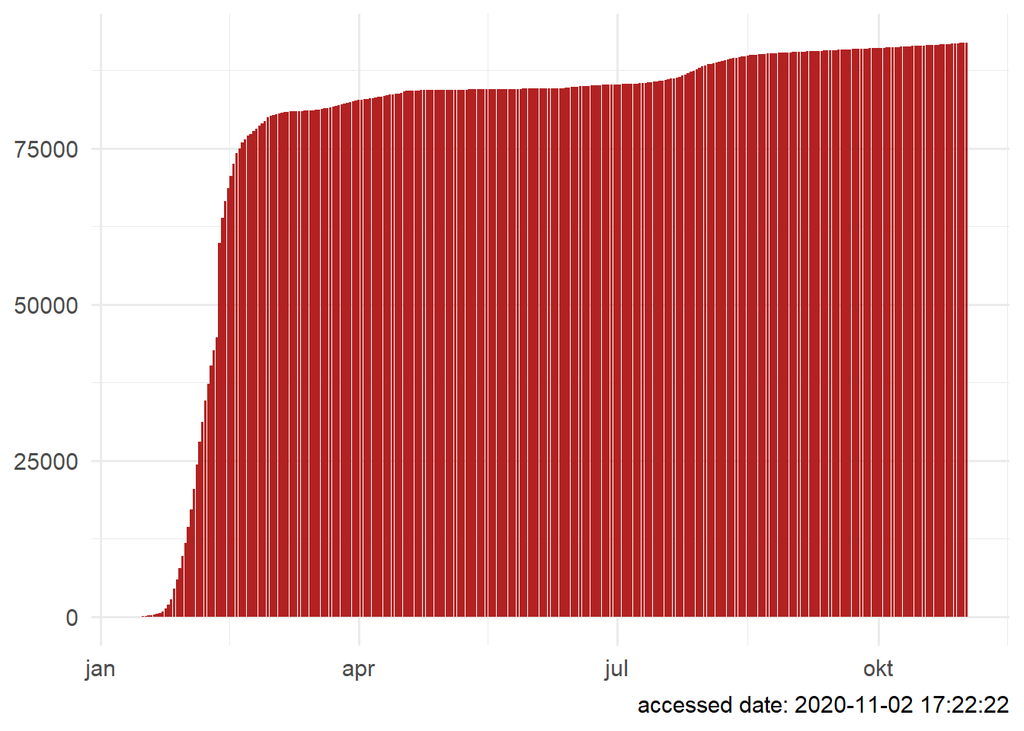

```r
library(ggplot2)
ggplot(summary(x), aes(as.Date(date, "%m.%d"), as.numeric(confirm))) +
  geom_col(fill='firebrick') + theme_minimal(base_size = 14) +
  xlab(NULL) + ylab(NULL) +
  labs(caption = paste("accessed date:", time(x)))
```

# World Map

Getting a plot of the world map takes only three lines (uncomment the first two if you skipped the chunks above:

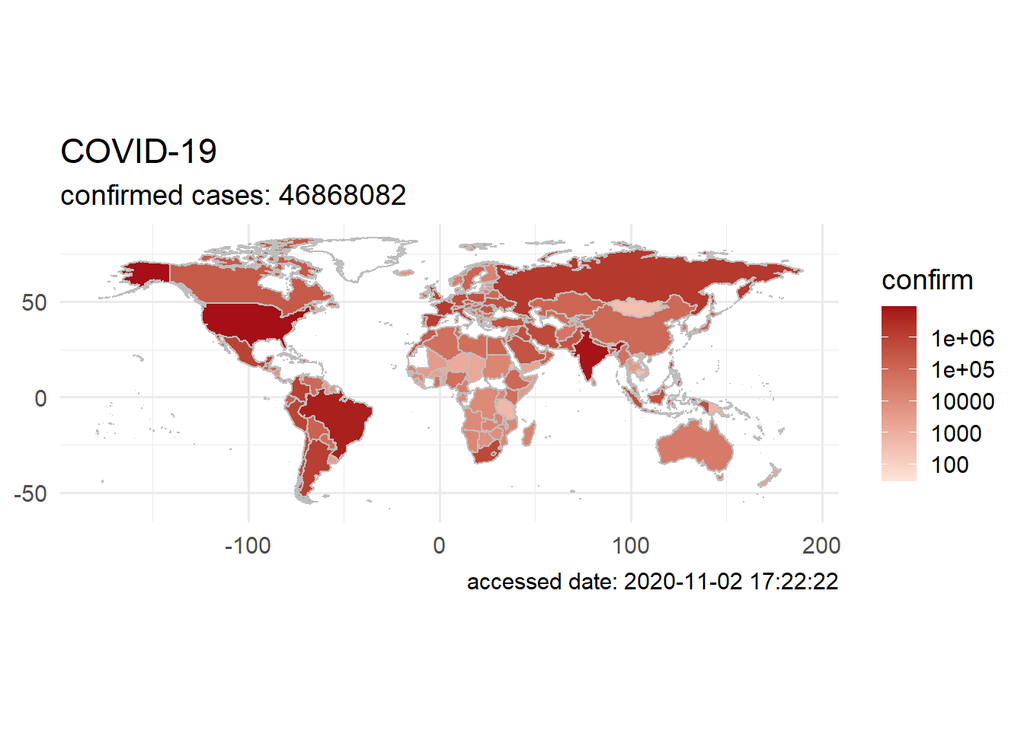

```r
# require(nCov2019)
# x = get_nCov2019(lang='en')
plot(x)
```

## Global data

To look at the global data, you subset the dataset via `x['global']`:

```r
#x <- get_nCov2019(lang = 'en') # uncomment if you did not run the chunks above
world <- x['global']
head(world, 12)
```

```
##              name confirm suspect   dead deadRate showRate    heal healRate
## 1           China   91966       1   4746     5.16    FALSE   86684    94.26
## 2   United States 9473911       0 236471      2.5    FALSE 6103605    64.43
## 3           India 8229313       0 122607     1.49    FALSE 7544798    91.68
## 4          Brazil 5545705       0 160074     2.89    FALSE 5022338    90.56
## 5          Russia 1642665       0  28264     1.72    FALSE 1228921    74.81
## 6          France 1458999       0  37057     2.54    FALSE  123664     8.48
## 7           Spain 1264517       0  35878     2.84    FALSE  196958    15.58
## 8       Argentina 1173533       0  31140     2.65    FALSE  985316    83.96
## 9        Colombia 1082767       0  31796     2.94    FALSE  977371    90.27
## 10 United Kingdom 1038054       0  46807     4.51    FALSE    2841     0.27
## 11         Mexico  929392       0  91895     9.89    FALSE  786516    84.63
## 12           Peru  902503       0  34476     3.82    FALSE  825197    91.43
##    showHeal
## 1      TRUE
## 2     FALSE
## 3     FALSE
## 4     FALSE
## 5     FALSE
## 6     FALSE
## 7     FALSE
## 8     FALSE
## 9     FALSE
## 10    FALSE
## 11    FALSE
## 12    FALSE
```

## Plot global data

Confirmed cases in absolute numbers

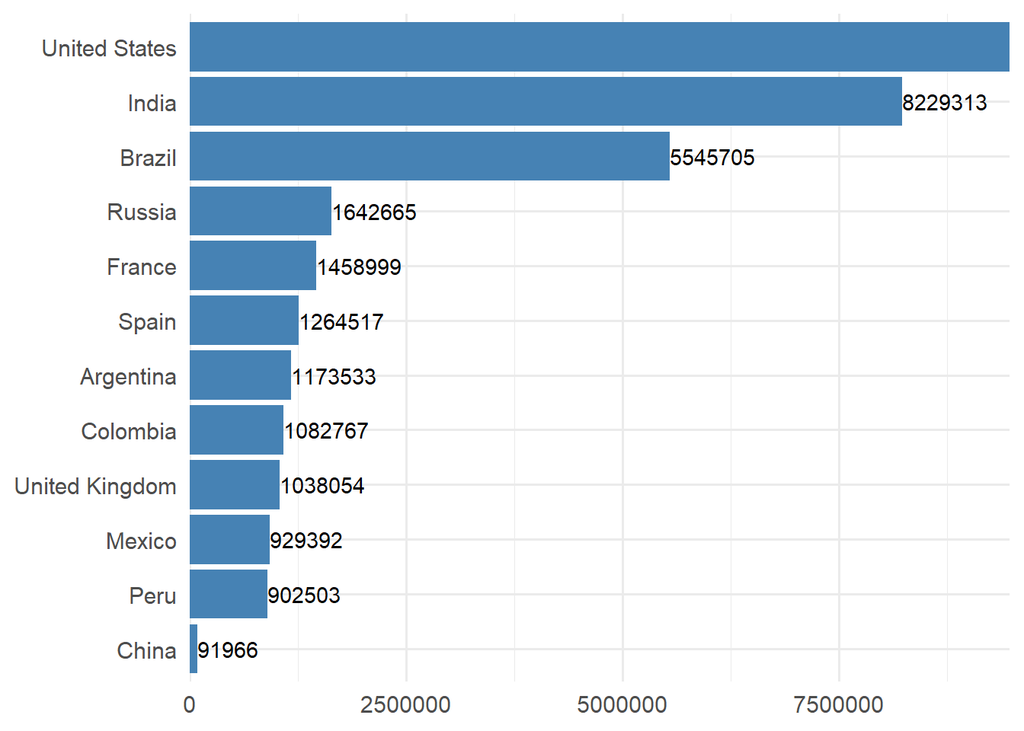

```r
library(forcats)
library(ggplot2)
d = head(world,12) # 12 most affected countries in absolute numbers
d$confirm=as.numeric(d$confirm)
d$name = fct_reorder(d$name, d$confirm)
ggplot(d, aes(name, confirm)) +
  geom_col(fill='steelblue') + coord_flip() +
  geom_text(aes(y = confirm+2, label=confirm), hjust=0) +
  theme_minimal(base_size=14) +
  scale_y_continuous(expand=c(0,10)) +
  xlab(NULL) + ylab(NULL)
```

Plot it by the death rate

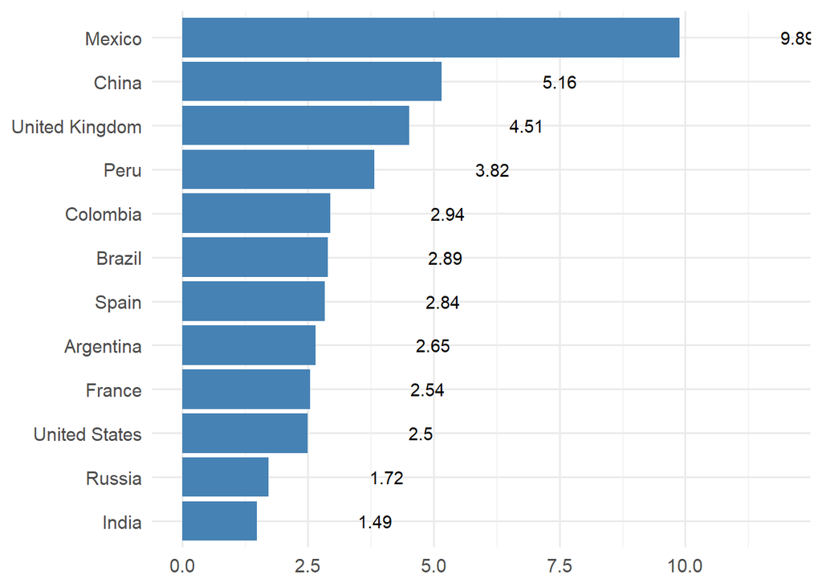

```r
library(forcats)
library(ggplot2)
d = head(world,12) # 12 most affected countries in absolute numbers
d$deadRate=as.numeric(d$deadRate)
d$name = fct_reorder(d$name, d$deadRate)
ggplot(d, aes(name, deadRate)) +
  geom_col(fill='steelblue') + coord_flip() +
  geom_text(aes(y = deadRate+2, label=deadRate), hjust=0) +
  theme_minimal(base_size=14) +
  scale_y_continuous() +
  xlab(NULL) + ylab(NULL)
```

## Global historical data

To look at the global historical data in `ncov2019` package, you need to use the `load_nCov2019` function and then subset via `y['global', ]`. Beware the difference between `get_nCov2019` and `load_nCov2019` in using the current data, and historical data respectively!

The data is organized around daily events (it is long).

```r
y <- load_nCov2019(lang = 'en')
d <- y['global',]
head(d)
```

```
##         time country cum_confirm cum_heal cum_dead
## 1 2019-12-01   China           1        0        0
## 2 2019-12-02   China           1        0        0
## 3 2019-12-03   China           1        0        0
## 4 2019-12-04   China           1        0        0
## 5 2019-12-05   China           1        0        0
## 6 2019-12-06   China           1        0        0
```

# Build up a heatmap of the global situation in the last 7 days

Here we will build an overview of the global landscape of coronavirus in one condensed tiled chart. We will use the global list from the historical `nCov2019` package created in the chunk above.

Next, we limit the time to go back 7 days and filter out all missing values. We set the colors to change with exponential differences to counts and sort the countries by number of confirmed cases

```r
max_time <- max(d$time)
min_time <- max_time - 7
d <- na.omit(d[d$time >= min_time & d$time <= max_time,])  # we are selecting values in the last 7 days
d <- d[d$cum_confirm>100000,] # I want to declutter and only show seriously affected countries
dd <- d[d$time == max(d$time, na.rm = TRUE),]
d$country <- factor(d$country,
                    levels=dd$country[order(dd$cum_confirm)])   # we want countries sorted by number of cases
breaks = c(10, 100, 1000, 10000, 100000, 1000000, 10000000)
```

Finally, we can plot the result with geom_tile()

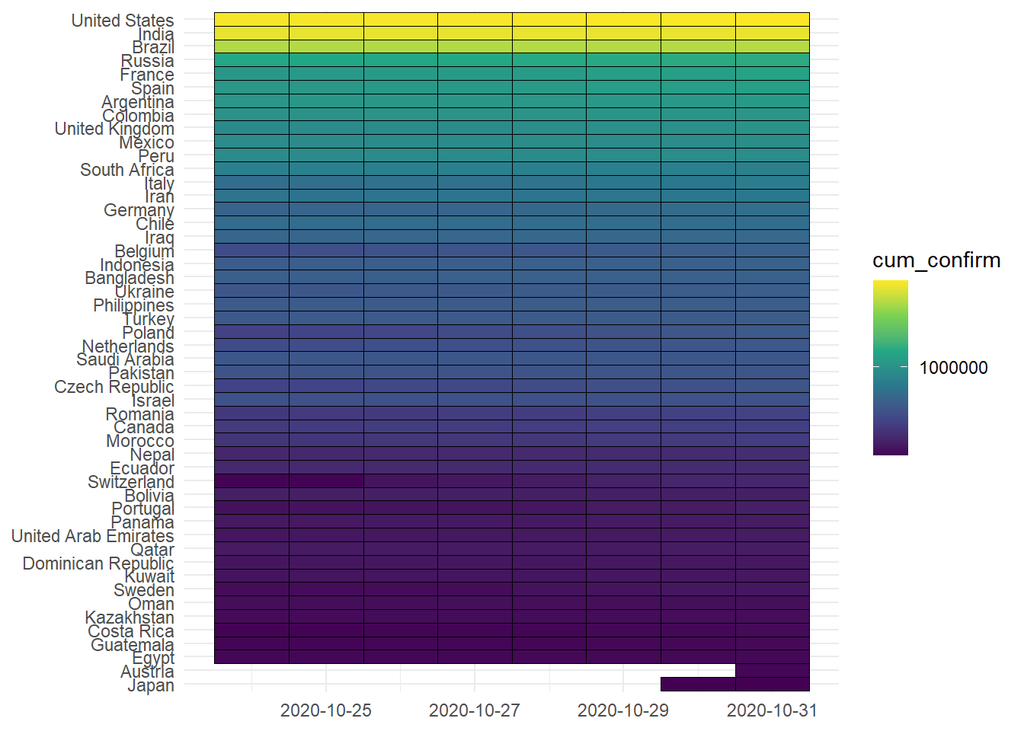

```r
options( scipen = 20 ) # I want to display full (unscientific) numbers
ggplot(d, aes(time, country)) +
  geom_tile(aes(fill = cum_confirm), color = 'black') +
  scale_fill_viridis_c(trans = 'log', breaks = breaks,
                       labels = breaks) +
  xlab(NULL) + ylab(NULL) +
  scale_x_date(date_labels = "%Y-%m-%d") + theme_minimal()
```

*Task 1: Can you change the heatmap to display the cases where patients died or healed?*

*Task 2: Can you change the heatmap to display the changing infection or death rate per million in the last seven days? Hint: you might need to scrape the countries’ population, and calculate this rate before changing the heatmap display.*

## Little detour to Belgium and the Czech Republic

A colleague in Belgium told me last week, that while the Czech Republic has been getting press for rising infection rates, the death toll was much much higher in Belgium already in the spring, despite the fact that the two countries have similar sized population (11.6 and 10.7 mil people respectively) and Belgium being much richer. Let’s pull out the information for Belgium and Czech Republic.

Just to have clean full dataset, we may wish to rerun the data loading.

```r
y <- load_nCov2019(lang = 'en')
a <- y['global',]
head(a, 12)
```

```
##          time country cum_confirm cum_heal cum_dead
## 1  2019-12-01   China           1        0        0
## 2  2019-12-02   China           1        0        0
## 3  2019-12-03   China           1        0        0
## 4  2019-12-04   China           1        0        0
## 5  2019-12-05   China           1        0        0
## 6  2019-12-06   China           1        0        0
## 7  2019-12-07   China           1        0        0
## 8  2019-12-08   China           1        0        0
## 9  2019-12-09   China           1        0        0
## 10 2019-12-10   China           1        0        0
## 11 2019-12-11   China           4        0        0
## 12 2019-12-12   China           4        0        0
```

```r
library(tidyverse)
bc <- a %>%
  filter(country == "Belgium" | country == "Czech Republic")
head(bc)
```

```
##         time country cum_confirm cum_heal cum_dead
## 1 2020-02-06 Belgium           1        0        0
## 2 2020-02-07 Belgium           1        0        0
## 3 2020-02-08 Belgium           1        0        0
## 4 2020-02-09 Belgium           1        0        0
## 5 2020-02-10 Belgium           1        0        0
## 6 2020-02-11 Belgium           1        0        0
```

Let’s check the situation in both places

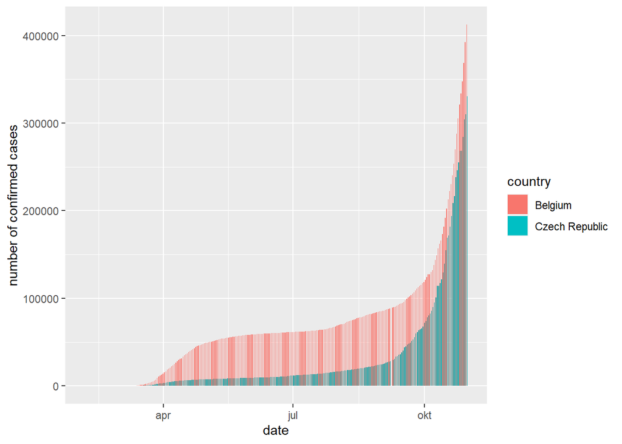

```r
ggplot(bc, aes(time, as.numeric(cum_confirm))) +
 geom_col(aes(fill = country), position = "dodge" )+
  labs( x = "date", y = "number of confirmed cases" )
```

```r
bc <- bc %>%
  mutate(pop = case_when(country == "Czech Republic" ~ 10700000,
                                country == "Belgium" ~ 11600000),
         rate_confirm = cum_confirm/pop, rate_dead = cum_dead/pop)
```

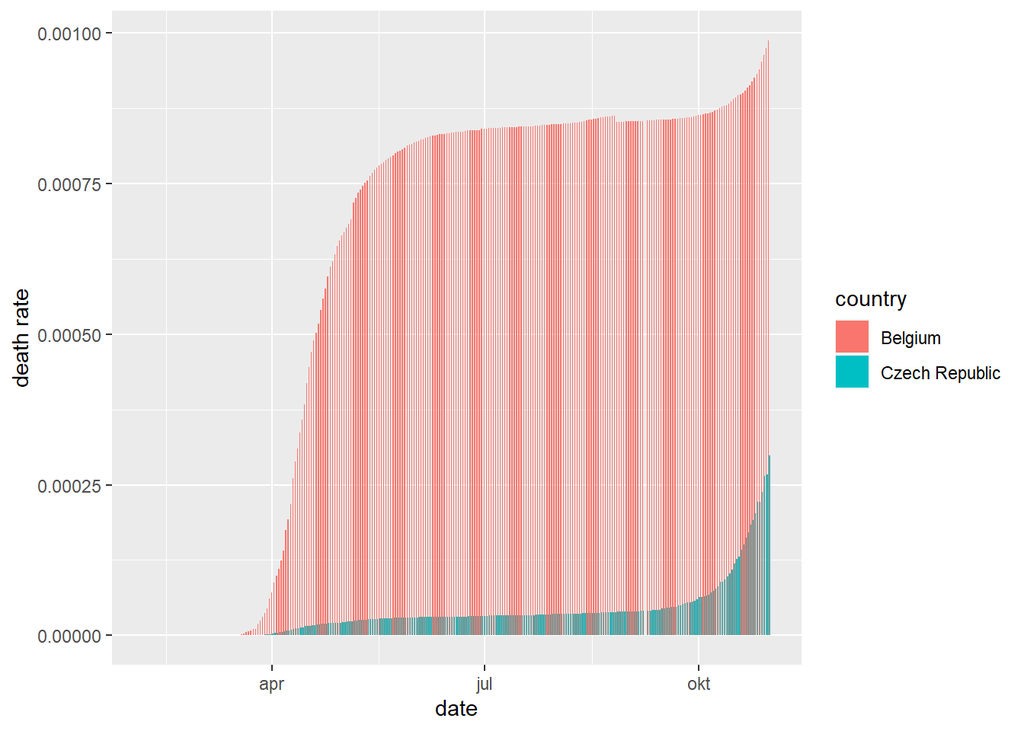

```r
ggplot(bc, aes(time, as.numeric(rate_dead))) +
 geom_col(aes(fill = country), position = "dodge" )+
  labs( x = "date", y = "death rate" )
```

I see that my colleague was right as far as the death rates go. What could be behind this difference? Was Belgium more lax about the spring lockdown? Were hospitals overwhelmed or were senior homes seriously compromised? Do we see the effect of higher population density or greater proportion of aging population (or high density of politicians)?

*Task 3: Formulate a proposition about the difference between Belgium and CZ death cases and investigate it using any data you can find.*

# Bibliography and other resources

If you use `nCov2019`, please cite the following preprint:

Tianzhi Wu, Erqiang Hu, Xijin Ge*, Guangchuang Yu*. Open-source analytics tools for studying the COVID-19 coronavirus outbreak. medRxiv, 2020.02.25.20027433. doi: https://doi.org/10.1101/2020.02.25.20027433